# Assignment 1

# Question 11

### a

```r
data11 = read.csv('VOLTAGE.csv')
#head(data11)

oldvolt = data11[data11$LOCATION == 'OLD',]
sort(oldvolt[,1])
```

```
##  [1]  8.05  8.72  8.72  8.80  9.55  9.70  9.73  9.80  9.80  9.84  9.84  9.87
## [13]  9.87  9.95  9.97  9.98  9.98 10.00 10.01 10.02 10.03 10.05 10.05 10.12
## [25] 10.15 10.15 10.26 10.26 10.29 10.55
```

```r
data11a = read.csv('Q11.csv')
print(data11a)
```

```
##   ï..class interval_low interval_high data.tab freq rel_freq
## 1        1       8.0000        8.2889  8.14445    1   0.0333
## 2        2       8.2889        8.5778  8.43335    0   0.0000
## 3        3       8.5778        8.8667  8.72225    3   0.1000
## 4        4       8.8667        9.1556  9.01115    0   0.0000
## 5        5       9.1556        9.4445  9.30005    0   0.0000
## 6        6       9.4445        9.7334  9.58895    3   0.1000
## 7        7       9.7334       10.0223  9.87785   13   0.4333
## 8        8      10.0223       10.3112 10.16675    9   0.3000
## 9        9      10.3112       10.6001 10.45565    1   0.0333
```

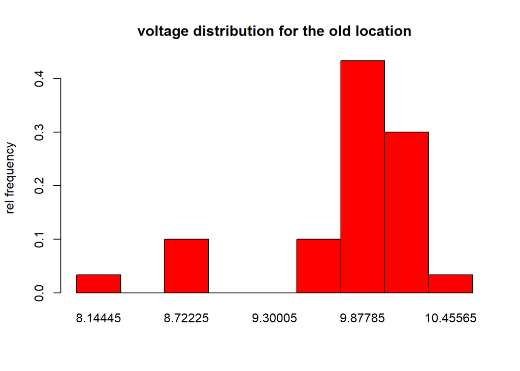

```r
barplot(data11a$rel_freq, space = 0, ylab = 'rel frequency', names.arg = data11a$data.tab, main = 'voltage distribution for the old location', col = 'red')
```

### b

```r
stem(oldvolt[,1])
```

```
##
##   The decimal point is at the |
##
##    8 | 1
##    8 | 778
##    9 |
##    9 | 677888899
##   10 | 0000000011122333
##   10 | 6
```

The stem plot shows one peak, which if you only care about the mode, this might be a better plot. But I personally like the rel freq graph on **a** better because it shows not only where the mode is, but also the entire distribution of the data.

### c

```r
newvolt = data11[data11$LOCATION == 'NEW',]
sort(newvolt[,1])
```

```
##  [1]  8.51  8.65  8.68  8.78  8.82  8.82  8.83  9.14  9.19  9.27  9.35  9.36
## [13]  9.37  9.39  9.43  9.48  9.49  9.54  9.60  9.63  9.64  9.70  9.75  9.85
## [25] 10.01 10.03 10.05 10.09 10.10 10.12
```

```r
data11c = read.csv('Q11c.csv')
print(data11c)
```

```
##   ï..class interval_low interval_high data_tab freq rel_freq
## 1        1       8.0000        8.2889  8.14445    0   0.0000
## 2        2       8.2889        8.5778  8.43335    1   0.0333
## 3        3       8.5778        8.8667  8.72225    6   0.2000
## 4        4       8.8667        9.1556  9.01115    1   0.0333
## 5        5       9.1556        9.4445  9.30005    7   0.2333
## 6        6       9.4445        9.7334  9.58895    7   0.2333
## 7        7       9.7334       10.0223  9.87785    3   0.1000
## 8        8      10.0223       10.3112 10.16675    5   0.1667
## 9        9      10.3112       10.6001 10.45565    0   0.0000
```

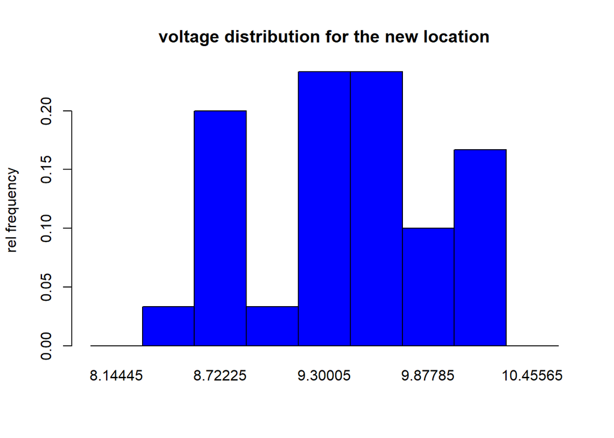

```r
barplot(data11c$rel_freq, space = 0, ylab = 'rel frequency', names.arg = data11c$data_tab, main = 'voltage distribution for the new location', col = 'blue')
```

### d

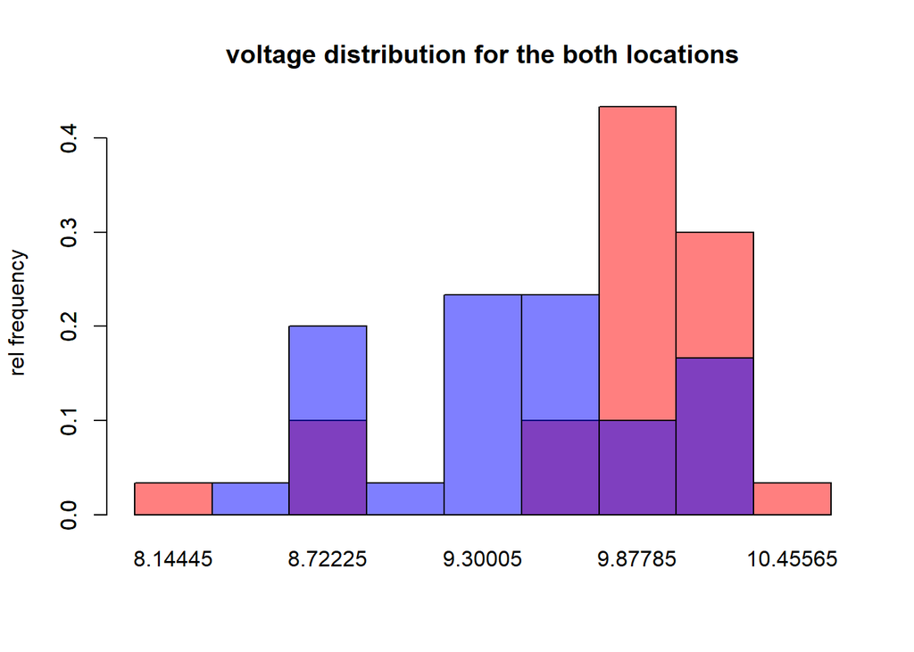

```r
barplot(data11a$rel_freq, space = 0, ylab = 'rel frequency', names.arg = data11a$data.tab, main = 'voltage distribution for the both locations', col=rgb(1,0,0,0.5))

barplot(data11c$rel_freq, space = 0, add = T, col=rgb(0,0,1,0.5))
```

From the chart above and with definition of ‘good’ being voltage >= 9.2V, we see that most of the data from both locations lie above 9.2V. In short, local production is acceptable. Nonetheless, the old location seems to produce more with greater voltage, which is better.

### e

```r
Mode <- function(x) {
  ux <- unique(x)
  ux[which.max(tabulate(match(x, ux)))]
}

meanOld = mean(oldvolt[,1])
medianOld = median(oldvolt[,1])
modeOld = Mode(oldvolt[,1])

meanOld
```

```
## [1] 9.803667
```

```r
medianOld
```

```
## [1] 9.975
```

```r
modeOld
```

```
## [1] 9.98
```

```r
meanNew = mean(newvolt[,1])
medianNew = median(newvolt[,1])
modeNew = Mode(newvolt[,1])

meanNew
```

```
## [1] 9.422333
```

```r
medianNew
```

```
## [1] 9.455
```

```r
modeNew
```

```
## [1] 8.82
```

The difference between the mean and the median is not significant for both locations. Additionally, the data distribution seems to contain most of the observations with close proximitiy to the mean. Hence, mean seems to be a better measure of central tendency.

### f

```r
z_old_f = (10.5 - meanOld) / sd(oldvolt[,1])
z_old_f
```

```
## [1] 1.287324
```

### g

```r
z_new_g = (10.5 - meanNew) /sd(newvolt[,1])
z_new_g
```

```
## [1] 2.25041
```

### h

Based on **f** and **g**, the voltage reading of 10.5V is more likely to occur in the old location. This is because the Z score is lower for the old location with respect to this reading, meaning its colser to the mean and has higher probability to occur at the old location.

### i

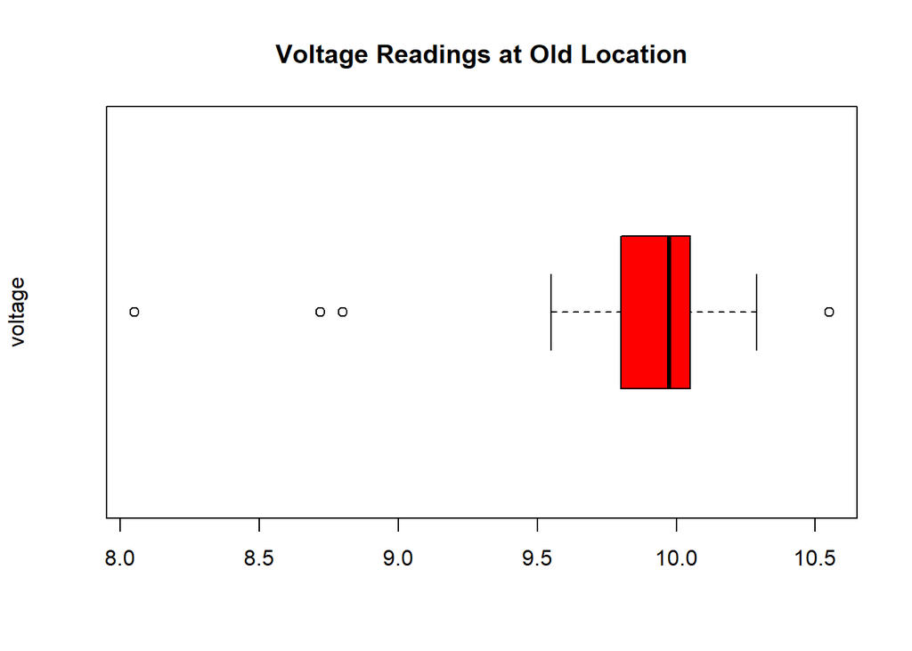

```r
boxplot(oldvolt[,1], ylab = 'voltage', col = 'red', horizontal = T, main = 'Voltage Readings at Old Location')
```

Yes, there seems to be some outliers as seen from the dotplot.

### j

```r
z_old = (oldvolt[,1] - meanOld) / sd(oldvolt[,1])
z_old
```

```
##  [1]  0.325990556  0.843631515  0.455400796  0.899093047  0.418426442
##  [6] -3.242034625  1.379759651  0.843631515  0.307503379  0.122631608
## [11]  0.584811036  0.455400796 -0.006778632  0.640272567  0.362964911
## [16]  0.122631608 -0.468958059  0.270529025 -0.191650403 -2.003393759
## [21]  0.067170077  0.640272567  0.399939265 -0.006778632 -0.136188871
## [26]  0.381452088  0.325990556 -2.003393759 -1.855496342  0.067170077
```

```r
old_detect = oldvolt[,1]
# Potential Outliers
print(old_detect[abs(z_old) > 2])
```

```
## [1] 8.05 8.72 8.72
```

```r
# Outliers
print(old_detect[abs(z_old) > 3])
```

```
## [1] 8.05
```

### k

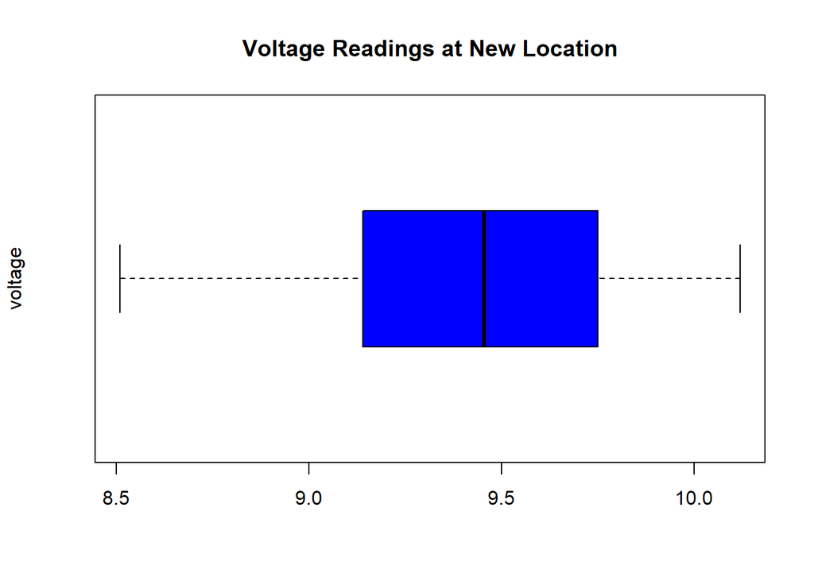

```r
boxplot(newvolt[,1], ylab = 'voltage', col = 'blue', horizontal = T, main = 'Voltage Readings at New Location')
```

The boxplot shows no radical outliers, but maybe some *potential* outliers

### l

```r
z_new = (newvolt[,1] - meanNew) / sd(newvolt[,1])
z_new
```

```
##  [1] -0.48516415  0.43365462  1.41512012  0.57983033  1.39423788  0.37100788
##  [7]  1.31070890  1.45688461  0.14130319 -0.10928375  1.22717992 -1.25780721
## [13]  0.01600972  1.26894441  0.89306400 -0.31810620 -1.23692497 -0.06751926
## [19]  0.12042095  0.45453686 -1.25780721 -1.61280538 -1.90515680 -0.58957538
## [25]  0.68424156 -1.34133619 -0.15104824  0.24571441 -0.13016599 -1.55015864
```

```r
new_detect = newvolt[,1]
# Potential outliers
print(new_detect[abs(z_new) > 2])
```

```
## numeric(0)
```

```r
# Outlier
print(new_detect[abs(z_new) > 3])
```

```
## numeric(0)
```

z-score method shows no outlier for the new location voltage readings

### m

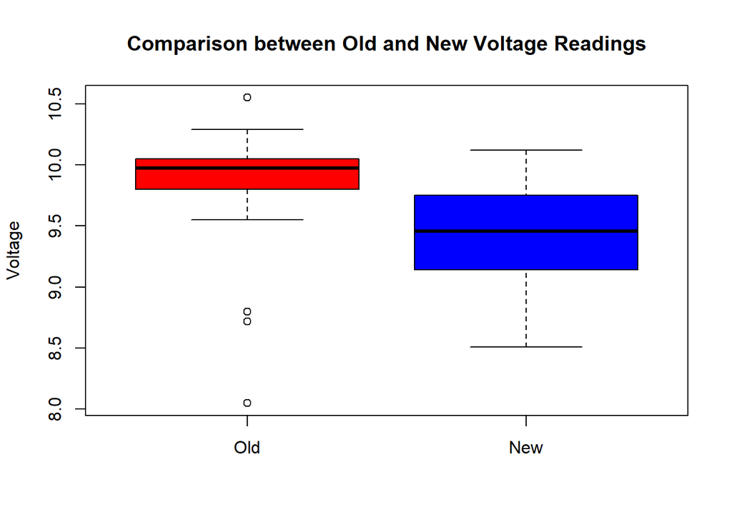

```r
box_join = data.frame("Old" = oldvolt[,1], "New" = newvolt[,1])

boxplot(box_join, col = c('red','blue'), main = 'Comparison between Old and New Voltage Readings', ylab = 'Voltage')
```

# Question 12

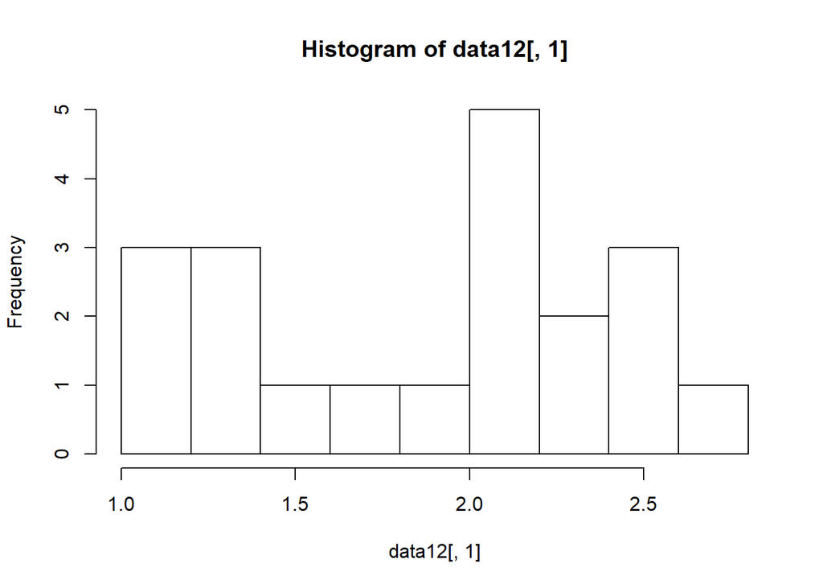

```r
library(ggplot2)
data12 = read.csv('ROUGHPIPE.csv')

hist(data12[,1])
```

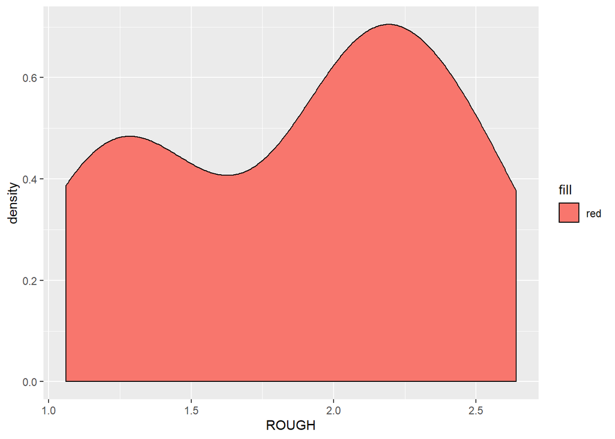

```r
g12 = ggplot(data12, aes(x = ROUGH)) + geom_density(aes(fill = 'red'))
g12
```

As we can see, the data is not normally distributed (not mound shape and not symmetric). Hence, we cannot use the empirical rule to estimate interval containing 95% of the data. Therefore, attempt to estimate interval likely to contain 95% of the data using Chebyshev’s rule.

$$N \geq 1 -\frac{1}{k^2}$$

When k = 3, at least 89% of the data is contained within 3 std dev of the mean. This is very close to 95%.

```r
mean12 = mean(data12[,1])
sd12 = sd(data12[,1])

mean12
```

```
## [1] 1.881
```

```r
3*sd12
```

```
## [1] 1.571734
```

Therefore, the interval likely to contain 95% of the data is
$$x = 1.881 \pm 1.572$$

# Question 13

## a

```r
data13 = read.csv('GOBIANTS.csv')
mean13 = mean(data13$AntSpecies)
median13 = median(data13$AntSpecies)


mode13 = Mode(data13$AntSpecies)

mean13
```

```
## [1] 12.81818
```

```r
median13
```

```
## [1] 5
```

```r
mode13
```

```
## [1] 5
```

The mean is 12.8182 and the median and mode are 5.

## b

Median seems to be a better measure of central tendency because some observation has erronously high number of species. Median is not sensitive to outliers.

## c

```r
drycover = data13$PlantCov[data13$Region == "Dry Steppe "]
meanDry = mean(drycover)
medianDry = median(drycover)
modeDry = Mode(drycover)

meanDry
```

```
## [1] 40.4
```

```r
medianDry
```

```
## [1] 40
```

```r
modeDry
```

```
## [1] 40
```

The mean of plant cover percentage for Dry Steppe region only is 40.4% while the median and the mode are both 40%.

## d

```r
gobicover = data13$PlantCov[data13$Region == "Gobi Desert"]
meanGob = mean(gobicover)
medianGob = median(gobicover)
modeGob = Mode(gobicover)

meanGob
```

```
## [1] 28
```

```r
medianGob
```

```
## [1] 26
```

```r
modeGob
```

```
## [1] 30
```

The mean of plant cover percentage for Gobi Desert region only is 28, the median is 26, and the mode is 30.

## e

Judging solely by total plant coverage, the center of plant cover percentage distribution from **d** and **c** suggests that they are distinct.

# Question 14

## a

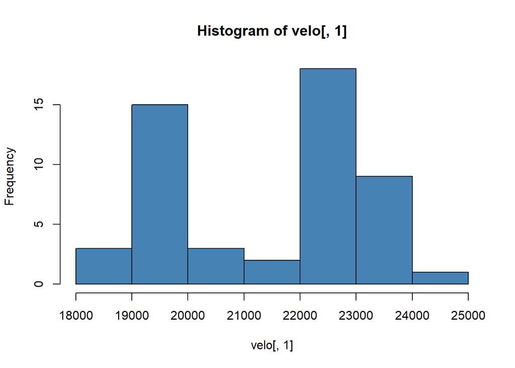

```r
velo = read.csv('GALAXY2.csv')
hist(velo[,1], col = 'steelblue')
```

```r
#d = ggplot(velo, aes(x = velo[,1])) + geom_histogram(binwidth = 200)
#d
```

Data distribution seems bimodal. Two peaks are observed, one at around 19500 km/s and the other at 22500 km/s.

## b

The apparent bimodal nature of the data suggests the presence of two different velocities, which implies the existence of more than one galaxies. Hence, the data distribution supports the idea of double cluster.

## c

```r
# Assuming double cluster, i set a treshold at 21000 km/s to distinguish the two clusters
# so A1775A has velocity < 21000 km/s and A1775B has volocity >= 21000 km/s

gal_a = velo[velo[,1] < 21000,]
gal_b = velo[velo[,1] >= 21000,]

meanA = mean(gal_a)
sdA = sd(gal_a)

meanB = mean(gal_b)
sdB = sd(gal_b)

meanA
```

```
## [1] 19462.24
```

```r
sdA
```

```
## [1] 532.2868
```

```r
meanB
```

```
## [1] 22838.47
```

```r
sdB
```

```
## [1] 560.9767
```

For cluster A1775A, the mean velocity is 19462.24 km/s and its std dev is 532.2868 km/s while for cluster A1775B, the mean velocity is 22838.47 km/s and its std dev is 560.9767 km/s.

## d

A galaxy with a velocity of 20000 km/s will likely to belong to A1775A (the one with lower velocities) because the 20000 km/s is approximately within one std dev of the mean of A1775A.

# Question 15

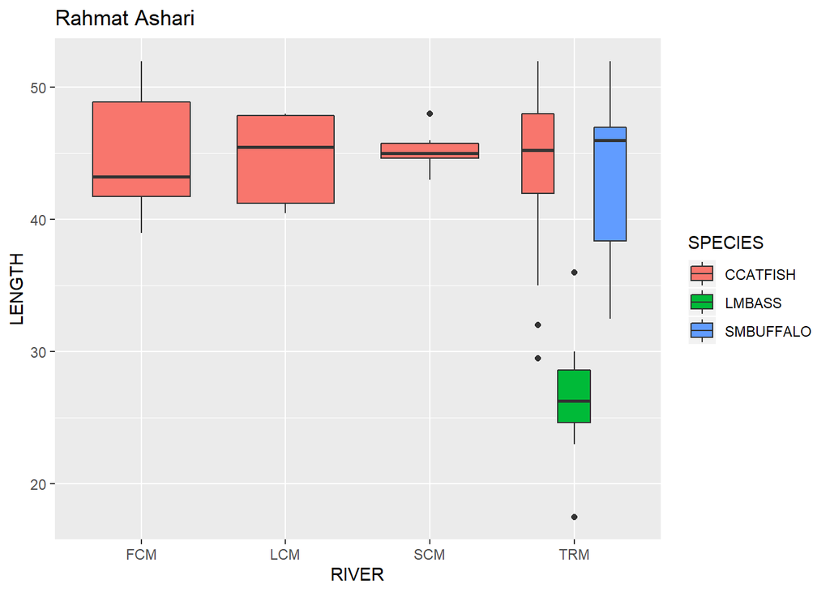

```r
g = ggplot(data = data, aes(x = RIVER, y = LENGTH)) + geom_boxplot(aes(fill = SPECIES)) + ggtitle('Rahmat Ashari')
g
```